# Question

En un curso de 12 estudiantes todos quieren sentarse en los 6 asientos de la primera fila, porque bajo los asientos hay un premio diferente para cada uno.

¿De cuántas formas puede asignar el profesor esos asientos?

## Answerlist

- de 665280 formas posibles
- de 924 formas posibles
- de 18 formas posibles
- de 665278 formas posibles

# Solution

Para llegar a la respuesta correcta debemos hacernos una serie de preguntas, siguiendo la ruta que nos mmuextra el siguiente árbol de decisión:

- ¿Están todos los elementos? No. La población (12) no es igual a la muestra (6).
- ¿Importa el orden? Sí. Hay un beneficio por ocupar un lugar específico.
- ¿Hay repetición? No. Un estudiante no puede ocupar más de un puesto a la vez
- Entonces, estamos ante un caso de Variación Sin Repetición (Opción 5):

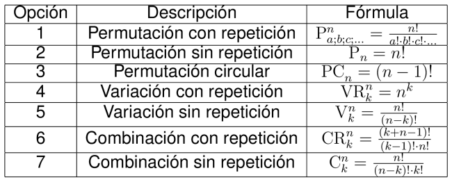

Por tanto, el profesor puede acomodar a los 12 estudiantes en los 6 asientos de la primera fila de 665280 formas.

## Answerlist

- Verdadero
- Falso
- Falso
- Falso

# Meta-information

exname:RadicalPrimo(single-choice) extype:schoice exsolution: 1000 exshuffle: TRUE